# Лабораторна робота №3

Anna Varych, KN-23-1, 2024

2024-11-28

# Постановка задачі

Випадкова величина $X$ має рівномірний розподіл $F(x; a, b)$, який задається формулою:

$$f(x; a, b) =
\begin{cases}
\frac{1}{b-a}, & x \in [a, b] \\
0, & x \notin [a, b]
\end{cases}$$

Параметри: $a = 0, b = 1$.

Для задачі ми вибрали параметри $a = 0, b = 1$, що означає рівномірний розподіл на інтервалі $[0, 1]$.

Мета лабораторної роботи: - Згенерувати вибірки обсягів $n = 100$ та $n = 1000$, - Оцінити параметри $a$ та $b$ за допомогою статистичних методів, - Побудувати графіки, які демонструють розподіл вибірок.

## Розв’язок задачі

### Генерація випадкових чисел

Згенеруємо вибірки з рівномірного розподілу для двох різних обсягів вибірки: $n = 100$ та $n = 1000$. Для цього будемо використовувати вбудовану функцію runif() у R.

```r
# Встановлення параметрів розподілу
a <- 0
b <- 1

# Генерація вибірок
set.seed(123)
sample1 <- runif(100, min = a, max = b)  # Вибірка розміром 100
sample2 <- runif(1000, min = a, max = b)  # Вибірка розміром 1000

# Виведення перших 6 значень для перевірки
head(sample1)
```

```
[1] 0.2875775 0.7883051 0.4089769 0.8830174 0.9404673 0.0455565
```

```r
head(sample2)
```

```
[1] 0.5999890 0.3328235 0.4886130 0.9544738 0.4829024 0.8903502
```

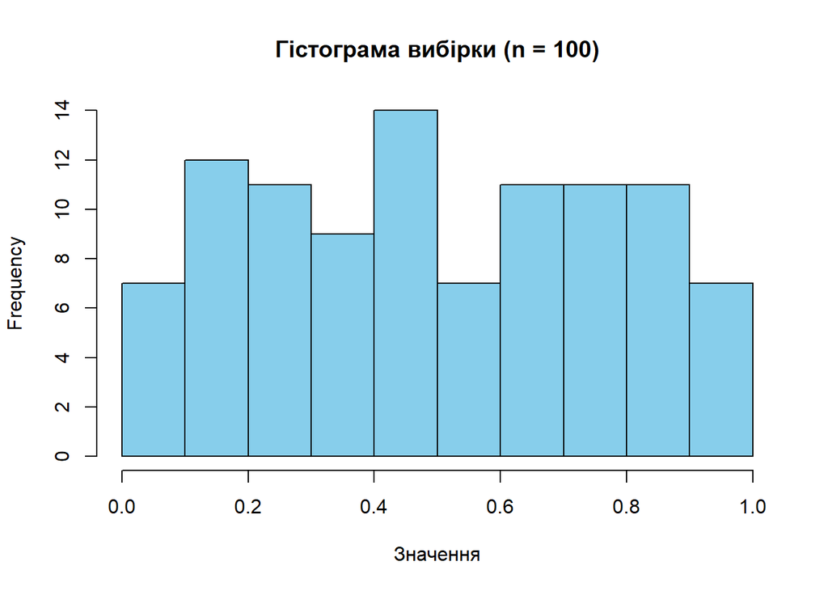

```r
# Побудова гістограми для вибірки розміром 100
hist(sample1,
     main = "Гістограма вибірки (n = 100)",
     xlab = "Значення",
     col = "skyblue",
     border = "black",
     freq = TRUE)
```

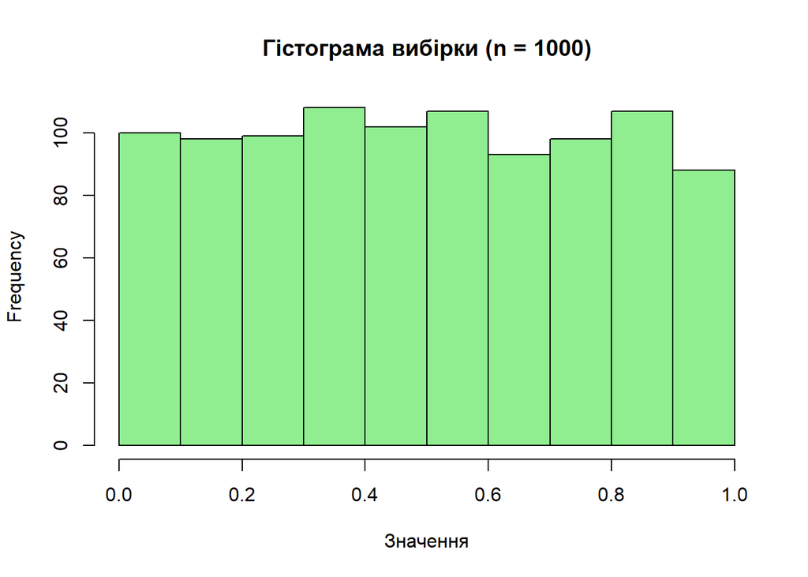

```r
# Побудова гістограми для вибірки розміром 1000
hist(sample2,
     main = "Гістограма вибірки (n = 1000)",
     xlab = "Значення",
     col = "lightgreen",
     border = "black",
     freq = TRUE)
```

```r
# Оцінка параметрів a та b для вибірок
estimated_a_100 <- min(sample1)
estimated_b_100 <- max(sample1)

estimated_a_1000 <- min(sample2)
estimated_b_1000 <- max(sample2)

cat("Оцінка параметрів для n = 100: a =", estimated_a_100, ", b =", estimated_b_100, "\n")
```

```
Оцінка параметрів для n = 100: a = 0.0006247733 , b = 0.9942698
```

```r
cat("Оцінка параметрів для n = 1000: a =", estimated_a_1000, ", b =", estimated_b_1000, "\n")
```

```
Оцінка параметрів для n = 1000: a = 0.0004653491 , b = 0.9994045
```

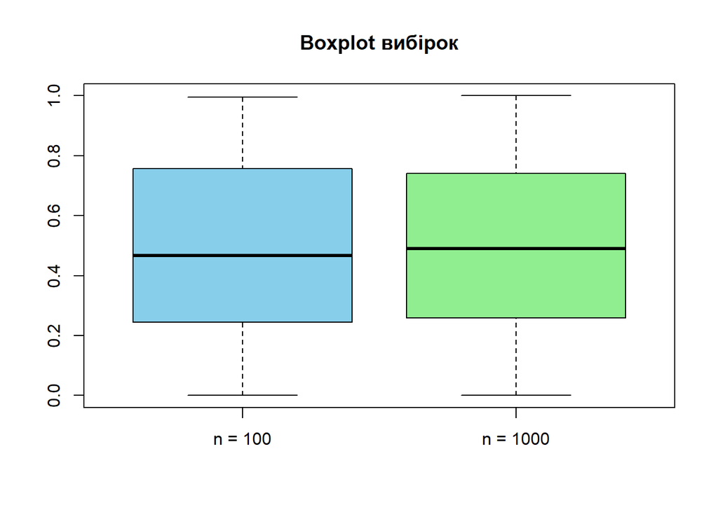

```r
# Побудова boxplot для порівняння вибірок
boxplot(sample1, sample2,
        names = c("n = 100", "n = 1000"),
        main = "Boxplot вибірок",
        col = c("skyblue", "lightgreen"))
```

## Висновки

У результаті виконання лабораторної роботи було досліджено рівномірний розподіл випадкової величини $X$ на відрізку $[0, 1]$ з параметрами $a = 0$ та $b = 1$.

1. Було згенеровано вибірки обсягів $n = 100$ та $n = 1000$, а також побудовано графіки для цих вибірок.
2. Оцінки параметрів $a$ та $b$ на основі згенерованих вибірок показали, що для великого розміру вибірки $n = 1000$ оцінки наближаються до реальних значень параметрів $a = 0, b = 1$.
3. Графіки, побудовані для кожної вибірки, показали, що з ростом обсягу вибірки результати стають більш стабільними та наближаються до ідеального рівномірного розподілу.
4. За допомогою оцінок та побудованих графіків можна зробити висновок про правильність заданого рівномірного розподілу і його параметрів, а також про залежність між обсягом вибірки та точністю оцінок.